# Racial diversity analysis of TCR sequencing data

Maia Bennett-Boehm

12/11/2023

This document contains the code utilized to conduct a basic analysis of race information in three publicly available TCR-pMHC (T cell receptor-peptide-major histocompatibility complex) binding datasets.

Library:

```r
library(readxl)
library(ggplot2)
library(plyr)
library(tidyverse)
library(ggpubr)
library(rstatix)
library(patchwork)
```

## Data import

This section imports TCR-pMHC binding data from 3 major, publicly available datasets: ImmuneCODE, McPAS, and VDJdb. These sources were selected due to their established use in prior publications coupled with their (mostly) separate sources of data, indicating that there should be minimal overlaps in data coverage.

```r
# File names: change as needed to indicate file locations
immuneCODE.subjects.file <- "C:/Users/Me/OneDrive - University of Nebraska at Omaha/Thesis/Datasets/ImmuneCODE/ImmuneCODE-MIRA-Release002/subject-metadata.csv"
immuneCODE.minigene.file <- "C:/Users/Me/OneDrive - University of Nebraska at Omaha/Thesis/Datasets/ImmuneCODE/ImmuneCODE-MIRA-Release002/minigene-detail.csv"
immuneCODE.peptide.file <- "C:/Users/Me/OneDrive - University of Nebraska at Omaha/Thesis/Datasets/ImmuneCODE/ImmuneCODE-MIRA-Release002/peptide-detail.csv"
tcrdb.dir <- "C:/Users/Me/OneDrive - University of Nebraska at Omaha/Thesis/Datasets/TCRdb/"
tcrdb.files <- list.files(path = tcrdb.dir, pattern = ".tsv", full.names = TRUE)
mcpas.file <- "C:/Users/Me/OneDrive - University of Nebraska at Omaha/Thesis/Datasets/McPAS-TCR.csv"
vdjdb.file <- "C:/Users/Me/OneDrive - University of Nebraska at Omaha/Thesis/Datasets/VDJdb/vdjdb.slim.txt"


# ImmunoCODE import
immuneCODE.subjects <- read.csv(immuneCODE.subjects.file)
immuneCODE.minigene <- read.csv(immuneCODE.minigene.file)
immuneCODE.peptide <- read.csv(immuneCODE.peptide.file)

# Merge race/ethnicity entries with same indication (Black or African American and African American)
immuneCODE.subjects$Race[immuneCODE.subjects$Race == "African American"] <- "Black or African American"

# Make column to indicate data availability by donor, experiment
immuneCODE.subjects$Availability <- ifelse(immuneCODE.subjects$Race=="N/A", "Not available", "Available")

# Join all metadata and sequence data
immuneCODE.minigene <- inner_join(immuneCODE.subjects, immuneCODE.minigene, by="Experiment")
immuneCODE.peptide <- inner_join(immuneCODE.subjects, immuneCODE.peptide, by="Experiment")
colnames(immuneCODE.peptide)[colnames(immuneCODE.peptide) == 'Amino.Acids'] <- "Amino.Acid"
immuneCODE.full <- rbind(select(immuneCODE.minigene, Experiment, Subject, Race, Availability, TCR.BioIdentity, HLA.A, HLA.B, HLA.C, Amino.Acid), select(immuneCODE.peptide, Experiment, Subject, Race, Availability, TCR.BioIdentity, HLA.A, HLA.B, HLA.C, Amino.Acid))

# Although source material indicates all TCR-pMHC entries are unique, check anyway; a small portion is removed
immuneCODE.full <- immuneCODE.full[!duplicated(immuneCODE.full[, c('TCR.BioIdentity', 'Amino.Acid', 'Subject')]), ]




# TCRdb import
# As TCRdb stores data by study, individual files are read in, aggregated, and duplicates removed
# Because it was not possible to detect redundant data without CDR loop information, TCRdb was removed from analysis
#tcrdb <- read.delim(tcrdb.files[1])
#for(i in 2:length(tcrdb.files)){
#  tcrdb.temp <- read.delim(tcrdb.files[i])
#  tcrdb <- rbind(tcrdb, tcrdb.temp)
#}

# Remove any duplicate entries between studies
#tcrdb <- tcrdb[!duplicated(tcrdb[c('RunId', 'AASeq', 'Vregion', 'Dregion', 'Jregion')]), ]


# McPAS import
mcpas<- read.csv(mcpas.file)

# Remove non-human entries
mcpas <- mcpas[mcpas$Species == 'Human', ]


# VDJdb import
vdjdb <- read.delim(vdjdb.file)

# Remove non-human entries
vdjdb <- vdjdb[vdjdb$species == 'HomoSapiens', ]


# Preliminary data filtering for redundancy
# Combine all data for data coverage analysis; retain CDR3, peptide
# Start with immune code
full <- immuneCODE.full[ , c('TCR.BioIdentity', 'Amino.Acid', 'Race', 'Availability')]

# Remove gene family information (located after '+' in field) for TCR.Bioidentity to get CDR3 sequence
full$TCR.BioIdentity <- gsub("\\+.*", "", full$TCR.BioIdentity)
colnames(full) <- c("CDR3", "Peptide", "Race", "Availability")

# Add data source signifier
full$Source <- "ImmuneCODE"

# Add VDJ
vdjdb.add <- data.frame(select(vdjdb, 'cdr3', 'antigen.epitope'), "VDJdb", "N/A", "Not available")
colnames(vdjdb.add) <- c("CDR3", "Peptide", "Source", "Race", "Availability")
full <- rbind(full, vdjdb.add)


# Add McPAS; because of data formatting in other datasets, break paired data into single CDR3 chains to find any redundant entries
mcpas.add <- data.frame(select(mcpas, 'CDR3.alpha.aa', 'Epitope.peptide'), "McPAS-TCR", "N/A", "Not available")
mcpas.add <- rbind(data.frame(select(mcpas, 'CDR3.beta.aa', 'Epitope.peptide'), "McPAS-TCR", "N/A", "Not available"))
colnames(mcpas.add) <- c('CDR3', 'Peptide', 'Source', "Race", "Availability")

# Remove n/a/ entries caused by missing peptide sequences, unpaired CDR3 sequences in original dataset
mcpas.add <- mcpas.add[!is.na(mcpas.add$Peptide), ]
mcpas.add <- mcpas.add[!is.na(mcpas.add$CDR3), ]

# Bind to aggregated data
full <- rbind(full, mcpas.add)


# Check all CDR3 + peptide sequences for duplicates and remove as necessary (binding pair count)
full$Redundant <- ifelse((!duplicated(full[, c('CDR3', 'Peptide')])), "Unique", "Redundant")
full$RedundantTCR <- ifelse((!duplicated(full[, 'CDR3'])), "Unique", "Redundant")
```

## Analysis: Distribution of self-reported race information

This section displays various binding data parameters (number of subjects, established TCR-pMHC binding pairs (‘hits’), and unique TCR bioidentities) by race/ethnicity in the ImmuneCODE dataset, the only major dataset which includes this factor. It also runs basic statistical association tests (Kruskal-Wallis) between subject race and the number of hits established per subjects.

### Establish counts

```r
# Get counts
# subject count by race
immuneCODE.subjects.unique <- immuneCODE.subjects[!duplicated(immuneCODE.subjects$Subject), ]
immuneCODE.counts <- count(immuneCODE.subjects.unique, Race, name = "Subject")

# Sample count by race
immuneCODE.counts <- cbind(immuneCODE.counts, count(immuneCODE.full, Race)[,2])
colnames(immuneCODE.counts)[3] <- "Binding.pairs"

# Filter unique TCR bioidentity and add unique TCR count by race
immuneCODE.TCRs.unique <- immuneCODE.full[!duplicated(immuneCODE.full$TCR.BioIdentity), ]
immuneCODE.counts <- cbind(immuneCODE.counts, count(immuneCODE.TCRs.unique, Race)[,2])
colnames(immuneCODE.counts)[4] <- "TCR.bioidentities"

immuneCODE.counts
```

```
##                                        Race Subject Binding.pairs
## 1                                     Asian       4          5215
## 2                 Black or African American       2          6301
## 3                      Hispanic or Latino/a       1           853
## 4                                Mixed Race       1           192
## 5                                       N/A      51         18029
## 6 Native Hawaiian or Other Pacific Islander       1           211
## 7                                     White      28        100149
##   TCR.bioidentities
## 1              5146
## 2              6000
## 3               825
## 4               192
## 5             16835
## 6               205
## 7             97282
```

```r
# Sample (binding pair) count by subject with associated race
immuneCODE.sample.counts <- count(immuneCODE.full, Subject, name = "Binding.pairs")
immuneCODE.sample.counts <- inner_join(immuneCODE.subjects.unique[, c('Race', 'Subject')], immuneCODE.sample.counts, by = "Subject")

immuneCODE.sample.counts
```

```
##                                         Race Subject Binding.pairs
## 1                                      White   15845           332
## 2                                      White    4423          2184
## 3                                      White    2060            61
## 4                                      White    7527            17
## 5                                      White    1483           270
## 6                                 Mixed Race    1780           192
## 7                                        N/A    3819           408
## 8                  Black or African American   20014            28
## 9                                        N/A    4611           215
## 10                                       N/A    6913           284
## 11                                       N/A    3211           178
## 12                                       N/A    3911           155
## 13                                       N/A  500001           882
## 14                                       N/A    1349           200
```

[output cut: 74 more lines]

```r
# Create counts without n/a
immuneCODE.counts.no.na <- immuneCODE.counts[immuneCODE.counts$Race != "N/A",]
immuneCODE.sample.counts.no.na <- immuneCODE.sample.counts[immuneCODE.sample.counts$Race != "N/A",]
```

### Data visualization

#### Distribution by subject

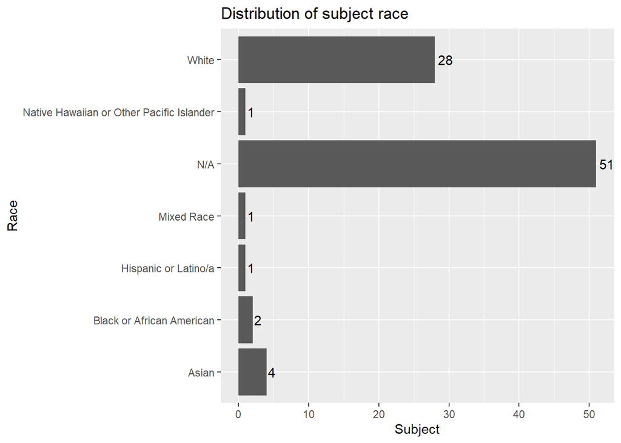

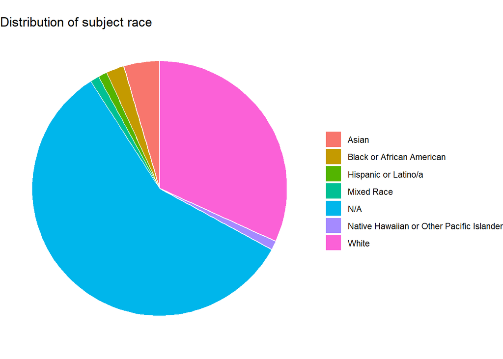

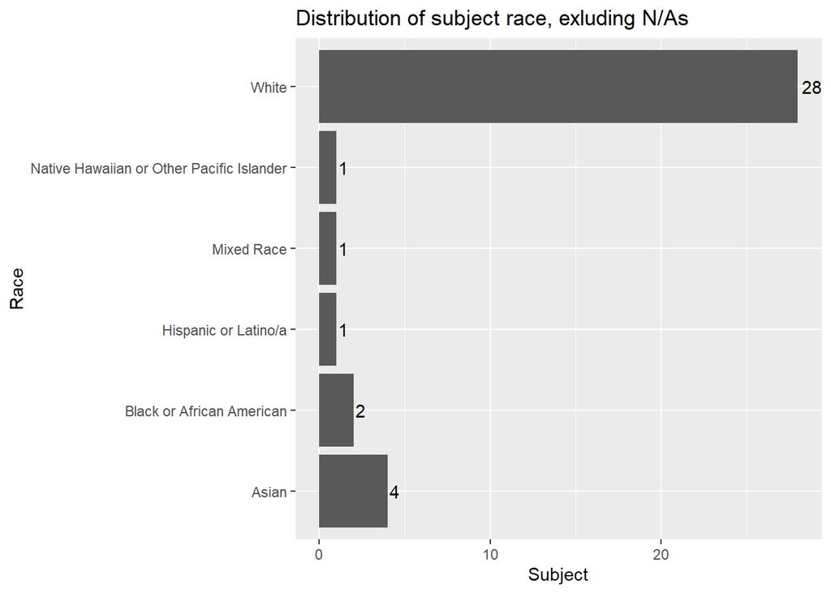

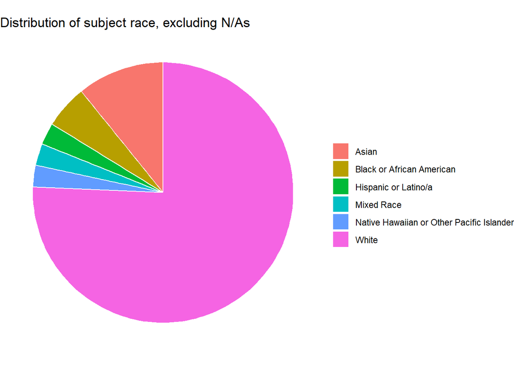

```r
# Plots
# subject counts with n/as
ggplot(immuneCODE.counts, aes(x=Race, y=Subject)) +
  geom_bar(stat="identity") +
  coord_flip() +
  ggtitle("Distribution of subject race") +
  geom_text(aes(label=Subject), hjust = -0.2)

ggplot(immuneCODE.counts, aes(x="", y=Subject, fill=Race)) +
  geom_bar(stat="identity", width=1, color="white") +
  coord_polar("y", start=0) +
  theme_void() + ggtitle("Distribution of subject race") +
  theme(legend.title=element_blank())

# Without n/as
ggplot(immuneCODE.counts.no.na, aes(x=Race, y=Subject)) +
  geom_bar(stat="identity") +
  coord_flip() +
  ggtitle("Distribution of subject race, exluding N/As") +
  geom_text(aes(label=Subject), hjust = -0.2)

ggplot(immuneCODE.counts.no.na, aes(x="", y=Subject, fill=Race)) +
  geom_bar(stat="identity", width=1, color="white") +
  coord_polar("y", start=0) +
  theme_void() + ggtitle("Distribution of subject race, excluding N/As") +
  theme(legend.title=element_blank())
```

#### Distribution by binding pairs

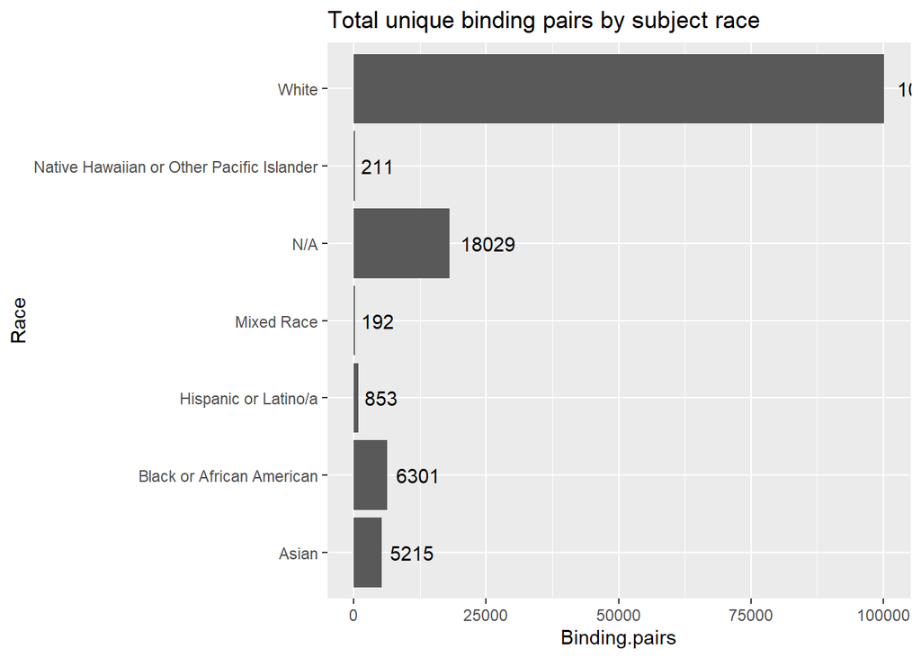

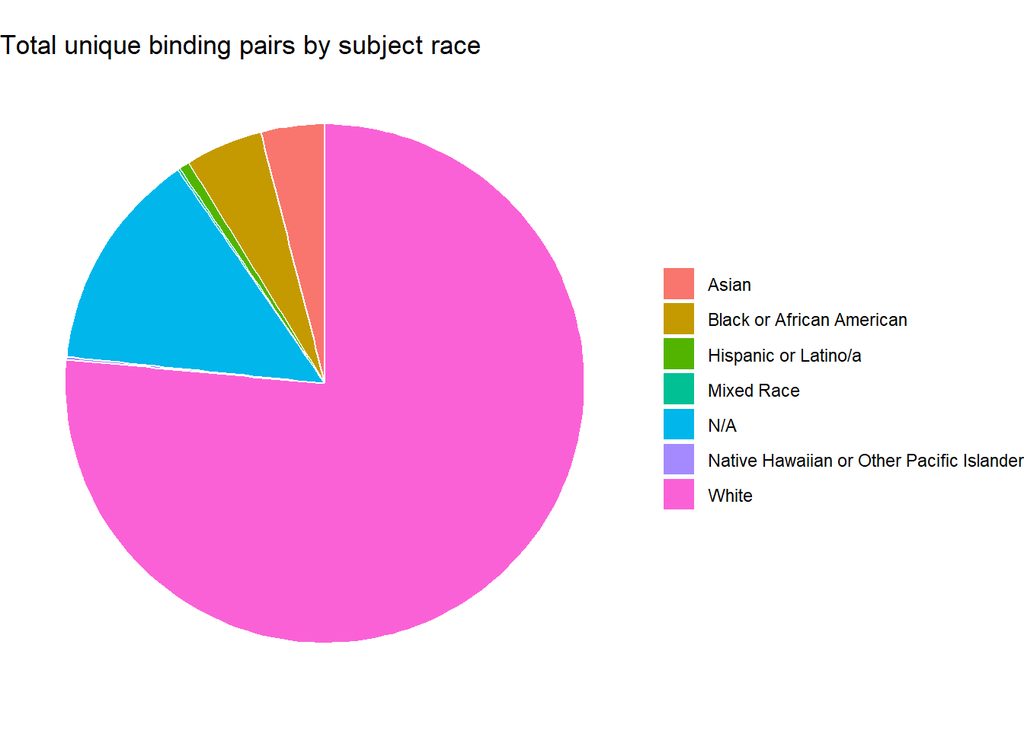

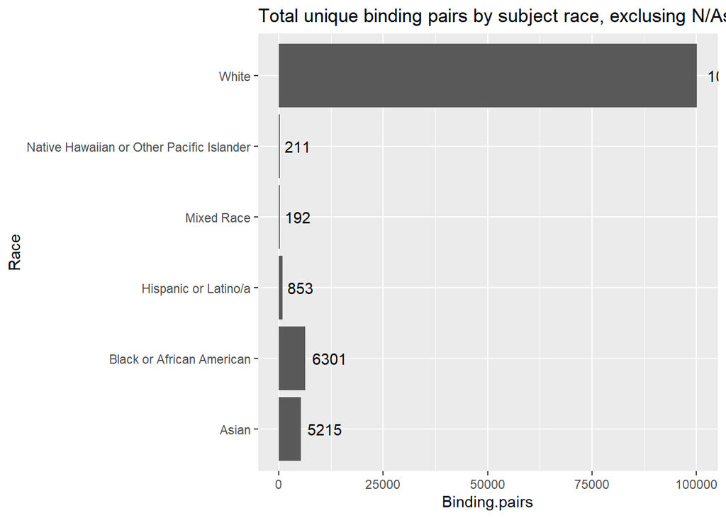

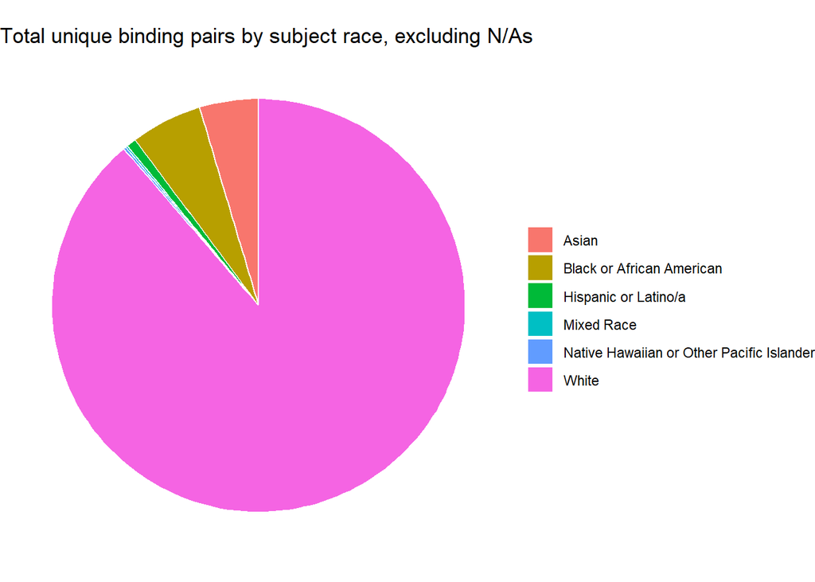

```r
# Sample counts with NAs
ggplot(immuneCODE.counts, aes(x=Race, y=Binding.pairs)) +
  geom_bar(stat="identity") +
  coord_flip() +
  ggtitle("Total unique binding pairs by subject race") +
  geom_text(aes(label=Binding.pairs), hjust = -0.2)

ggplot(immuneCODE.counts, aes(x="", y=Binding.pairs, fill=Race)) +
  geom_bar(stat="identity", width=1, color="white") +
  coord_polar("y", start=0) +
  theme_void() + ggtitle("Total unique binding pairs by subject race") +
  theme(legend.title=element_blank())

# Without n/as
ggplot(immuneCODE.counts.no.na, aes(x=Race, y=Binding.pairs)) +
  geom_bar(stat="identity") +
  coord_flip() +
  ggtitle("Total unique binding pairs by subject race, exclusing N/As") +
  geom_text(aes(label=Binding.pairs), hjust = -0.2)

ggplot(immuneCODE.counts.no.na, aes(x="", y=Binding.pairs, fill=Race)) +
  geom_bar(stat="identity", width=1, color="white") +
  coord_polar("y", start=0) +
  theme_void() + ggtitle("Total unique binding pairs by subject race, excluding N/As") +
  theme(legend.title=element_blank())
```

#### Distribution by unique TCR bioidenties

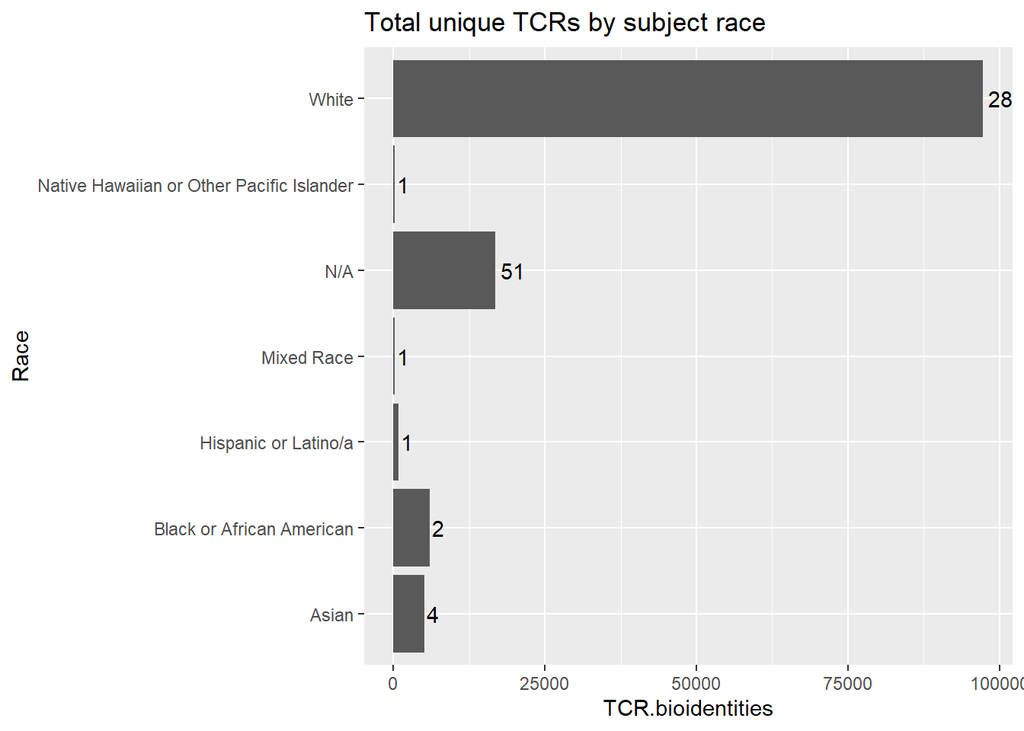

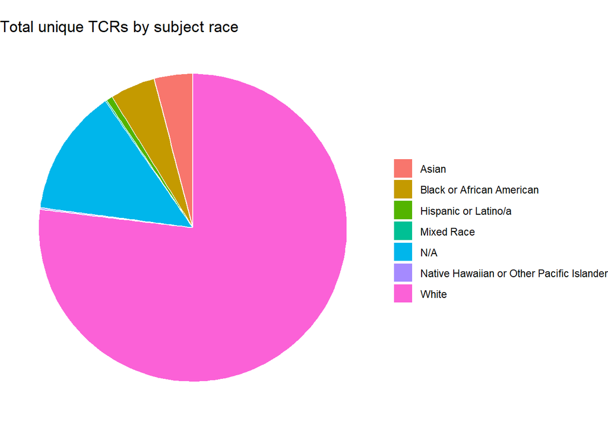

[figure not shown]

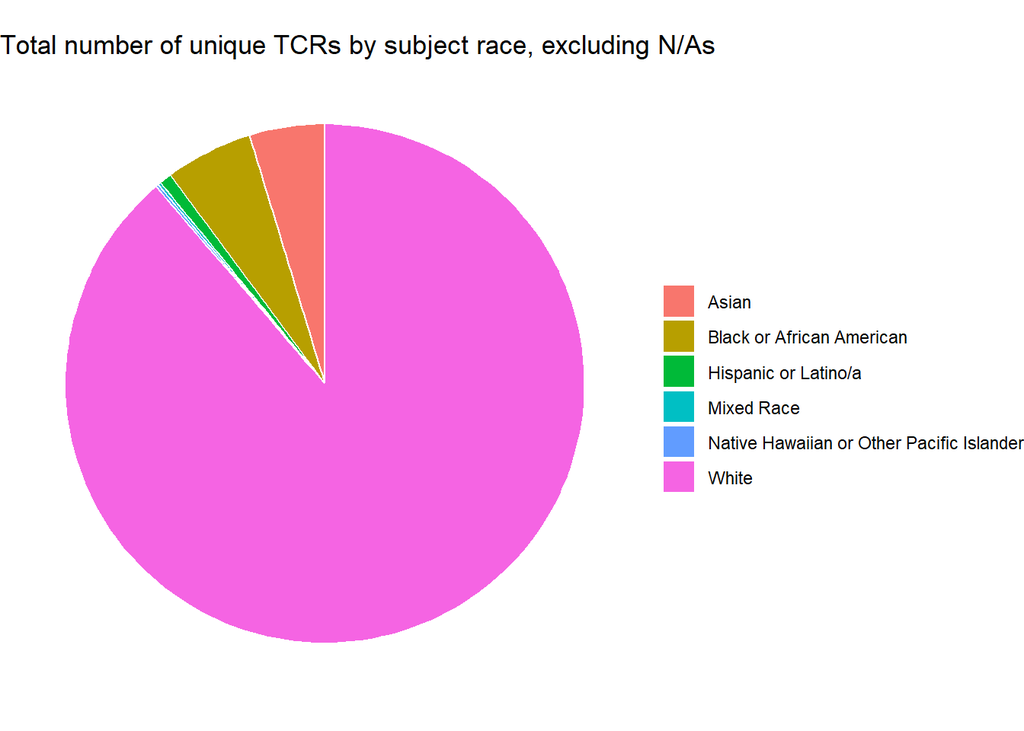

```r
# Unique TCR counts with NAs
ggplot(immuneCODE.counts, aes(x=Race, y=TCR.bioidentities)) +
  geom_bar(stat="identity") +
  coord_flip() +
  ggtitle("Total unique TCRs by subject race") +
  geom_text(aes(label=Subject), hjust = -0.2)

ggplot(immuneCODE.counts, aes(x="", y=TCR.bioidentities, fill=Race)) +
  geom_bar(stat="identity", width=1, color="white") +
  coord_polar("y", start=0) +
  theme_void() + ggtitle("Total unique TCRs by subject race") +
  theme(legend.title=element_blank())

# Without n/as
ggplot(immuneCODE.counts, aes(x=Race, y=TCR.bioidentities)) +
  geom_bar(stat="identity") +
  coord_flip() +
  ggtitle("Total unique TCRs by subject race, excluding N/As") +
  geom_text(aes(label=Subject), hjust = -0.2)

ggplot(immuneCODE.counts.no.na, aes(x="", y=TCR.bioidentities, fill=Race)) +
  geom_bar(stat="identity", width=1, color="white") +
  coord_polar("y", start=0) +
  theme_void() + ggtitle("Total number of unique TCRs by subject race, excluding N/As") +
  theme(legend.title=element_blank())
```

#### Data per subject

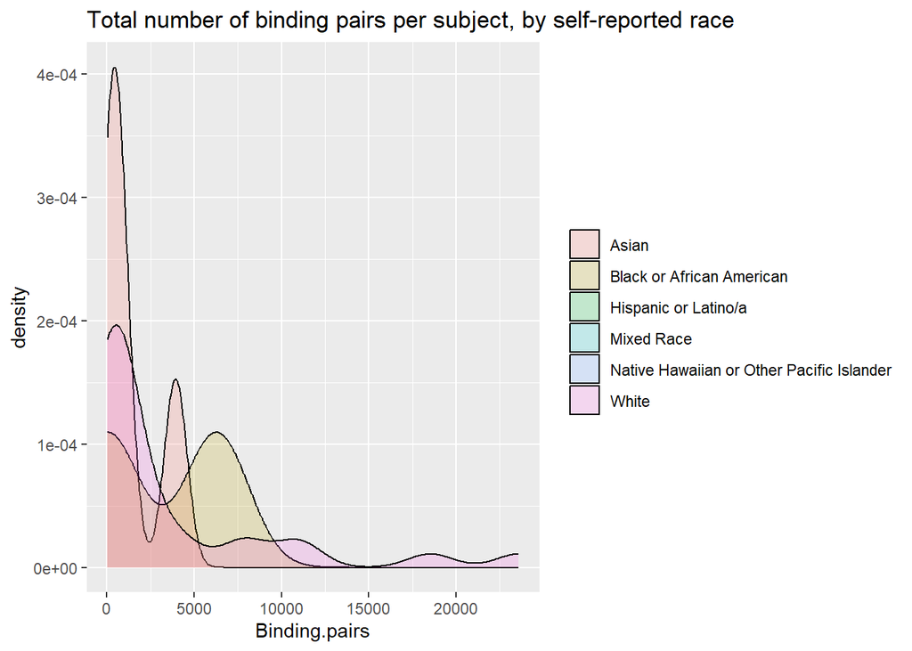

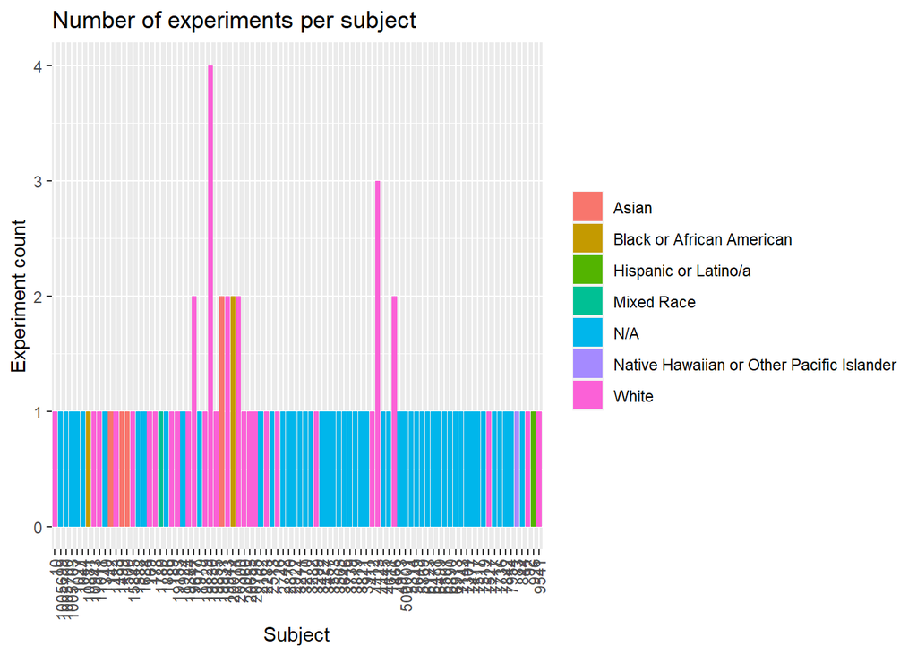

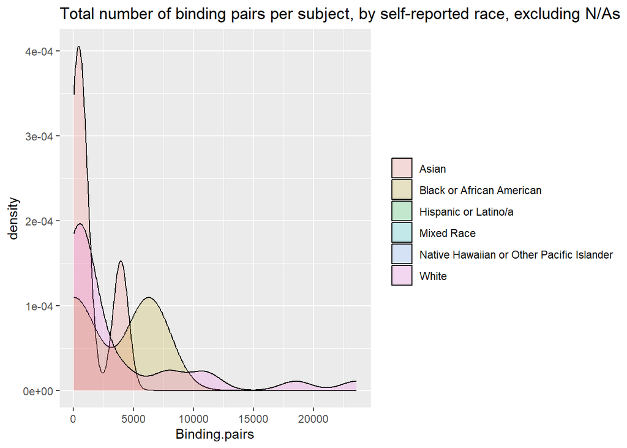

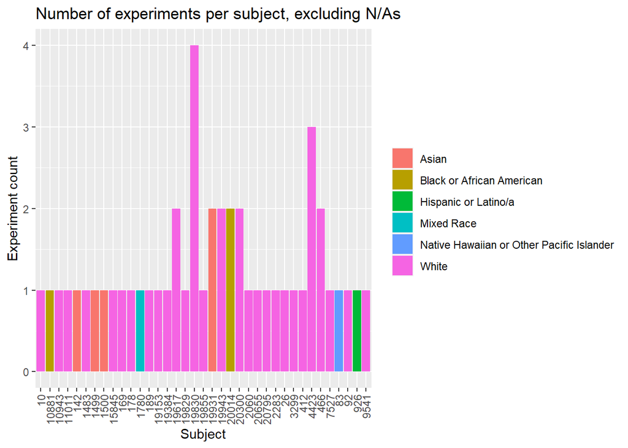

```r
# Race and binding pairs per subject histogram, with N/As
ggplot(immuneCODE.sample.counts.no.na, aes(x=Binding.pairs, fill = as.factor(Race))) +
  geom_density(alpha = 0.2) +
  theme(legend.title=element_blank()) +
  ggtitle("Total number of binding pairs per subject, by self-reported race")

# Experiments per donor
ggplot(immuneCODE.subjects, aes(x=as.character(Subject))) +
  geom_bar(stat="count", aes(fill=factor(Race))) +

  theme(axis.text.x = element_text(angle = 90, vjust = 0.5, hjust=1), legend.title=element_blank()) +
  labs(title="Number of experiments per subject",
        x ="Subject", y = "Experiment count")

# Race and binding pairs per subject histogram, no N/As
ggplot(immuneCODE.sample.counts.no.na, aes(x=Binding.pairs, fill = as.factor(Race))) +
  geom_density(alpha = 0.2) +
  theme(legend.title=element_blank()) +
  ggtitle("Total number of binding pairs per subject, by self-reported race, excluding N/As")

# Experiments per donor
ggplot(immuneCODE.subjects[immuneCODE.subjects$Race != "N/A", ], aes(x=as.character(Subject))) +
  geom_bar(stat="count", aes(fill=factor(Race))) +
  theme(axis.text.x = element_text(angle = 90, vjust = 0.5, hjust=1), legend.title=element_blank()) +
  labs(title="Number of experiments per subject, excluding N/As",
        x ="Subject", y = "Experiment count")
```

#### Statistics

```r
# Statistical association by Kruskal-Wallis test, with N/As
# Stats and box plot
immuneCODE.stats <- get_summary_stats(group_by(immuneCODE.sample.counts, Race))
immuneCODE.stats
```

```
## # A tibble: 14 × 14
##    Race     varia…¹     n   min    max median     q1     q3    iqr    mad   mean
##    <chr>    <fct>   <dbl> <dbl>  <dbl>  <dbl>  <dbl>  <dbl>  <dbl>  <dbl>  <dbl>
##  1 Asian    Subject     4   142 1.99e4  1500.  1160.  6108.  4948   1007.  5768
##  2 Asian    Bindin…     4    31 3.93e3   629    326.  1607   1281.   595.  1304.
##  3 Black o… Subject     2 10881 2.00e4 15448. 13164. 17731.  4566.  6770. 15448.
##  4 Black o… Bindin…     2    28 6.27e3  3150.  1589.  4712.  3122.  4629.  3150.
##  5 Hispani… Subject     1   926 9.26e2   926    926    926      0      0    926
##  6 Hispani… Bindin…     1   853 8.53e2   853    853    853      0      0    853
##  7 Mixed R… Subject     1  1780 1.78e3  1780   1780   1780      0      0   1780
##  8 Mixed R… Bindin…     1   192 1.92e2   192    192    192      0      0    192
##  9 N/A      Subject    51   844 1.01e6  3911   2896   7028   4132   3002. 73035.
## 10 N/A      Bindin…    51     9 2.26e3   186     96    374    278    162.   354.
## 11 Native … Subject     1    83 8.3 e1    83     83     83      0      0     83
## 12 Native … Bindin…     1   211 2.11e2   211    211    211      0      0    211
## 13 White    Subject    28    10 2.08e4  8534    452. 19670  19218. 12395.  9618.
## 14 White    Bindin…    28    17 2.36e4   706.   218.  4011.  3793.   948.  3577.
## # … with 3 more variables: sd <dbl>, se <dbl>, ci <dbl>, and abbreviated
## #   variable name ¹variable
```

```r
ggboxplot(immuneCODE.sample.counts, x = "Race", y = "Binding.pairs") +
  ggtitle("Total number of binding pairs per subject, by self-reported race") +
  scale_x_discrete(guide = guide_axis(n.dodge = 2))


immuneCODE.stats.kruskal <- kruskal.test(Binding.pairs ~ Race, data = immuneCODE.sample.counts)
immuneCODE.stats.kruskal # Not significant
```

```
##
##  Kruskal-Wallis rank sum test
##
## data:  Binding.pairs by Race
## Kruskal-Wallis chi-squared = 12.526, df = 6, p-value = 0.05121
```

```r
# Statistical association by Kruskal-Wallis test, no N/As
# Stats and box plot
immuneCODE.stats <- get_summary_stats(group_by(immuneCODE.sample.counts.no.na, Race))
immuneCODE.stats
```

```
## # A tibble: 12 × 14
##    Race      varia…¹     n   min   max median     q1     q3    iqr    mad   mean
##    <chr>     <fct>   <dbl> <dbl> <dbl>  <dbl>  <dbl>  <dbl>  <dbl>  <dbl>  <dbl>
##  1 Asian     Subject     4   142 19931  1500.  1160.  6108.  4948   1007.  5768
##  2 Asian     Bindin…     4    31  3926   629    326.  1607   1281.   595.  1304.
##  3 Black or… Subject     2 10881 20014 15448. 13164. 17731.  4566.  6770. 15448.
##  4 Black or… Bindin…     2    28  6273  3150.  1589.  4712.  3122.  4629.  3150.
##  5 Hispanic… Subject     1   926   926   926    926    926      0      0    926
##  6 Hispanic… Bindin…     1   853   853   853    853    853      0      0    853
##  7 Mixed Ra… Subject     1  1780  1780  1780   1780   1780      0      0   1780
##  8 Mixed Ra… Bindin…     1   192   192   192    192    192      0      0    192
##  9 Native H… Subject     1    83    83    83     83     83      0      0     83
## 10 Native H… Bindin…     1   211   211   211    211    211      0      0    211
## 11 White     Subject    28    10 20795  8534    452. 19670  19218. 12395.  9618.
## 12 White     Bindin…    28    17 23586   706.   218.  4011.  3793.   948.  3577.
## # … with 3 more variables: sd <dbl>, se <dbl>, ci <dbl>, and abbreviated
## #   variable name ¹variable
```

```
##
##  Kruskal-Wallis rank sum test
##
## data:  Binding.pairs by Race
## Kruskal-Wallis chi-squared = 1.959, df = 5, p-value = 0.8548
```

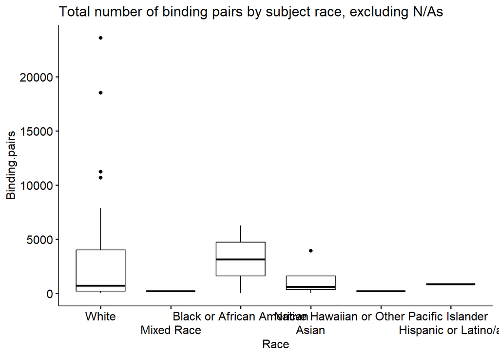

```r
ggboxplot(immuneCODE.sample.counts.no.na, x = "Race", y = "Binding.pairs") +
  ggtitle("Total number of binding pairs by subject race, excluding N/As") +
  scale_x_discrete(guide = guide_axis(n.dodge = 2))

immuneCODE.stats.kruskal <- kruskal.test(Binding.pairs ~ Race, data = immuneCODE.sample.counts.no.na)
immuneCODE.stats.kruskal # Not significant
```

## Race information availability analysis

This section displays the contribution of each dataset to the overall number of TCR repertoire data available, as well as the distribution of samples with and without associated subject race information.

### ImmuneCODE race information availability

#### Availability by subject

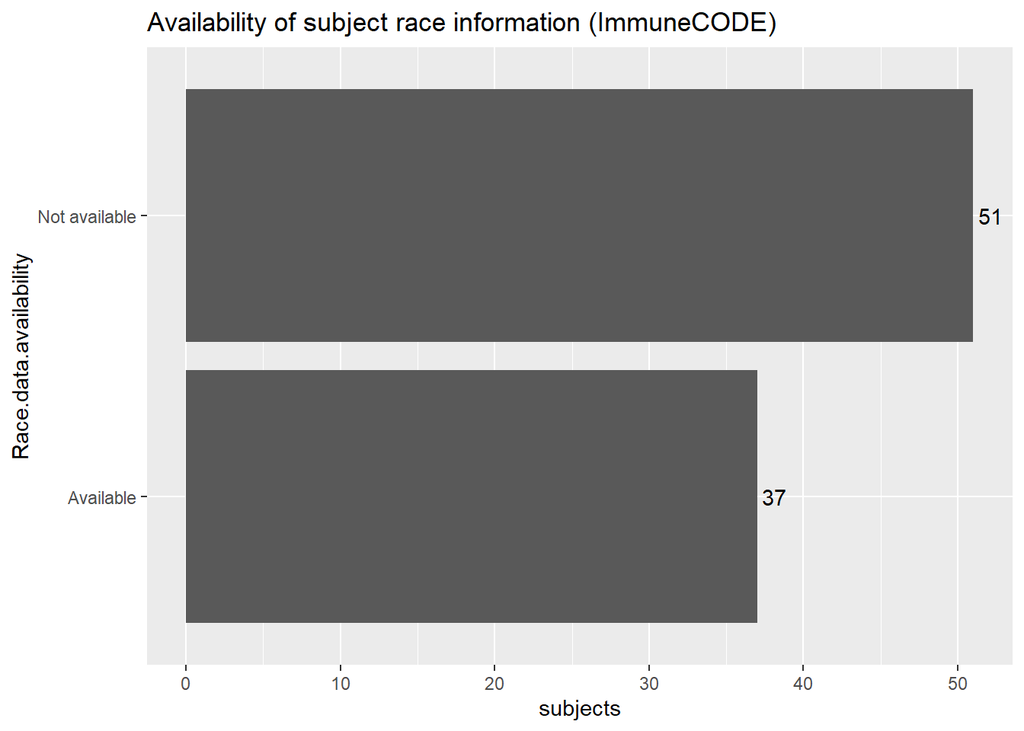

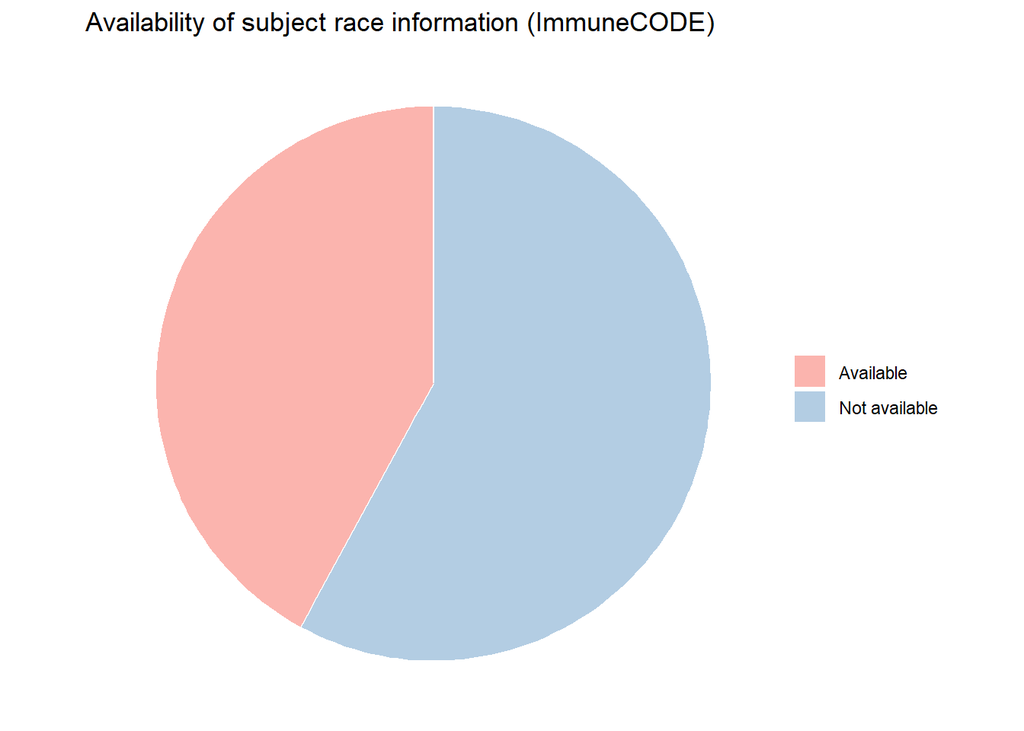

```r
# Distribution of available/unavailable in ImmuneCODE
immuneCODE.avail <- data.frame("Race.data.availability" = c("Available", "Not available"),
                                     "subjects" = c(nrow(immuneCODE.subjects.unique[immuneCODE.subjects.unique$Race != "N/A", ]),
                                                  (nrow(immuneCODE.subjects.unique[immuneCODE.subjects.unique$Race == "N/A", ]))),
                                     "Binding.pairs" = c(nrow(immuneCODE.full[immuneCODE.full$Race != "N/A", ]),
                                                        (nrow(immuneCODE.full[immuneCODE.full$Race == "N/A", ]))),
                                     "TCR.bioidentities" = c(nrow(immuneCODE.TCRs.unique[immuneCODE.TCRs.unique$Race != "N/A", ]),
                                                             (nrow(immuneCODE.TCRs.unique[immuneCODE.TCRs.unique$Race == "N/A", ]))))

# By donor
ggplot(immuneCODE.avail, aes(x=Race.data.availability, y=subjects)) +
  geom_bar(stat="identity") +
  coord_flip() +
  ggtitle("Availability of subject race information (ImmuneCODE)") +
  geom_text(aes(label=subjects), hjust = -0.2)

ggplot(immuneCODE.avail, aes(x="", y=subjects, fill=Race.data.availability)) +
  geom_bar(stat="identity", width=1, color="white") +
  coord_polar("y", start=0) +
  scale_fill_brewer(palette = "Pastel1") +
  theme_void() + ggtitle("Availability of subject race information (ImmuneCODE)") +
  theme(legend.title=element_blank())
```

#### Availability by binding pairs

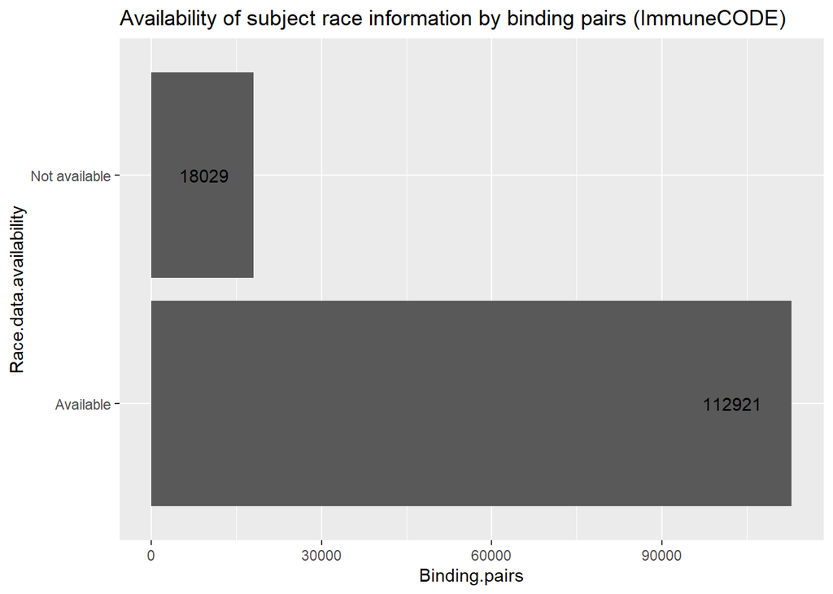

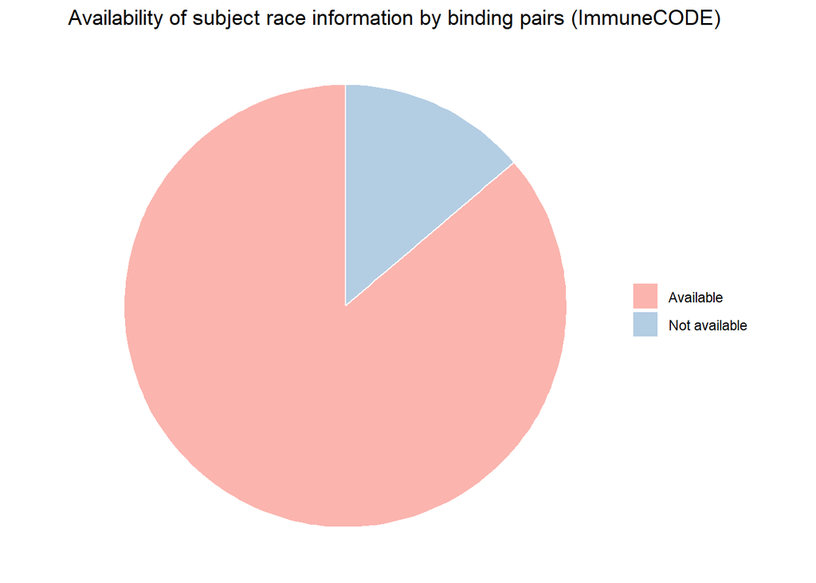

```r
# By binding pair
ggplot(immuneCODE.avail, aes(x=Race.data.availability, y=Binding.pairs)) +
  geom_bar(stat="identity") +
  coord_flip() +
  ggtitle("Availability of subject race information by binding pairs (ImmuneCODE)") +
  geom_text(aes(label=Binding.pairs), hjust = 1.5)

ggplot(immuneCODE.avail, aes(x="", y=Binding.pairs, fill=Race.data.availability)) +
  geom_bar(stat="identity", width=1, color="white") +
  coord_polar("y", start=0) +
  scale_fill_brewer(palette = "Pastel1") +
  theme_void() + ggtitle("Availability of subject race information by binding pairs (ImmuneCODE)") +
  theme(legend.title=element_blank())
```

#### Availability by unique TCR bioidentities

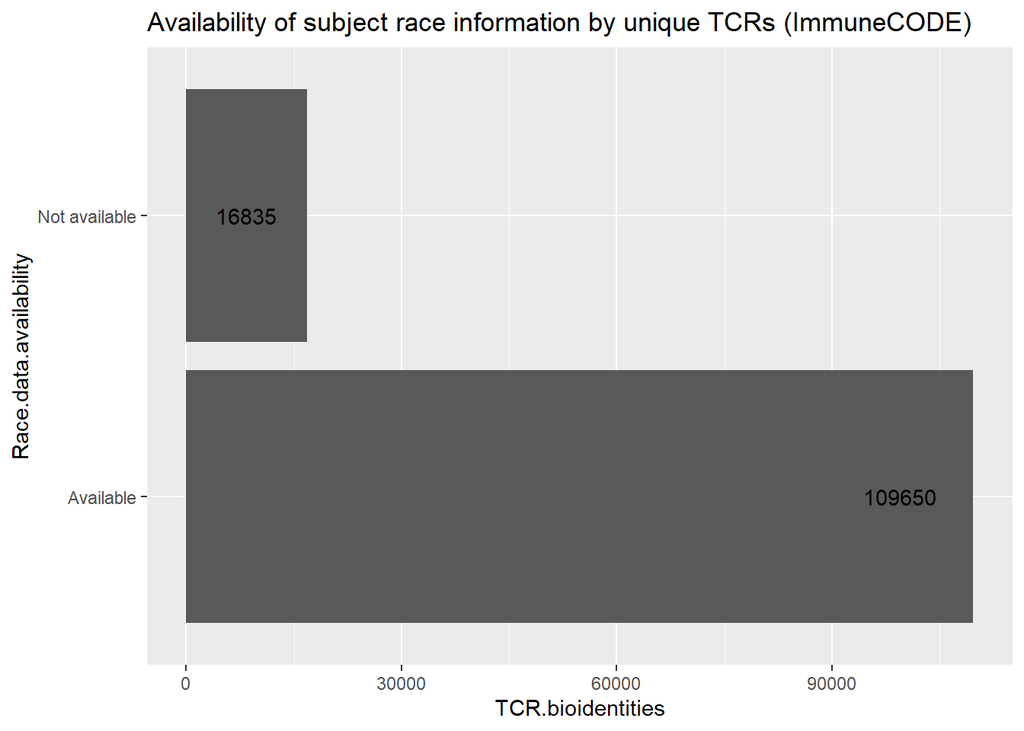

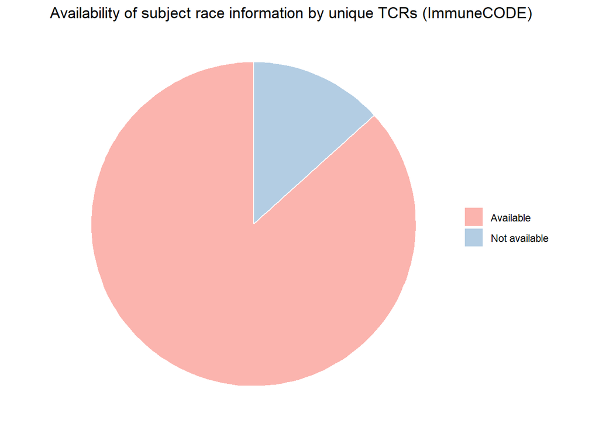

```r
# By unique TCR
ggplot(immuneCODE.avail, aes(x=Race.data.availability, y=TCR.bioidentities)) +
  geom_bar(stat="identity") +
  coord_flip() +
  ggtitle("Availability of subject race information by unique TCRs (ImmuneCODE)") +
  geom_text(aes(label=TCR.bioidentities), hjust = 1.5)

ggplot(immuneCODE.avail, aes(x="", y=TCR.bioidentities, fill=Race.data.availability)) +
  geom_bar(stat="identity", width=1, color="white") +
  scale_fill_brewer(palette = "Pastel1") +
  coord_polar("y", start=0) +
  theme_void() + ggtitle("Availability of subject race information by unique TCRs (ImmuneCODE)") +
  theme(legend.title=element_blank())
```

#### Data per subject

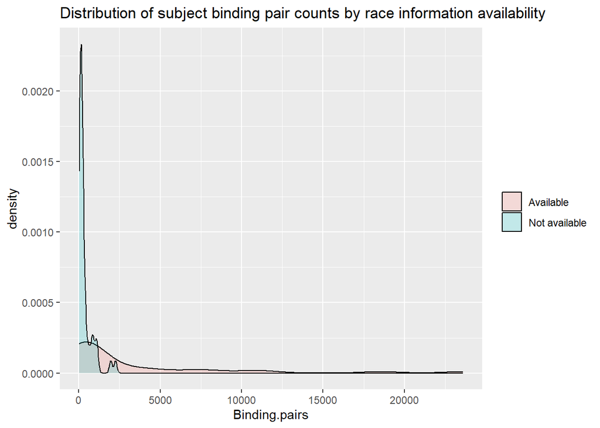

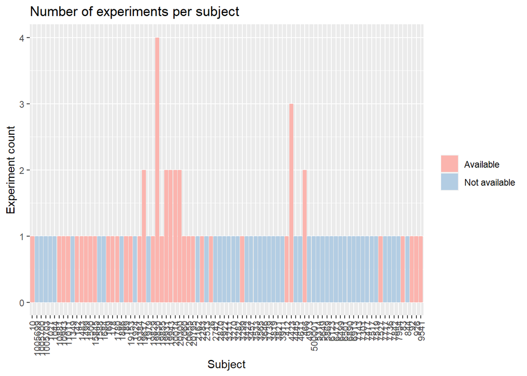

```r
# Get counts per subject
avail.counts <- immuneCODE.sample.counts
avail.counts$Race[avail.counts$Race != "N/A"] <- "Available"
avail.counts$Race[avail.counts$Race == "N/A"] <- "Not available"

# Histogram of binding pairs
ggplot(avail.counts, aes(x=Binding.pairs, fill = as.factor(Race))) +
  geom_density(alpha = 0.2) +
  theme(legend.title=element_blank()) +
  ggtitle("Distribution of subject binding pair counts by race information availability")

# Experiments per donor
ggplot(immuneCODE.subjects, aes(x=as.character(Subject))) +
  geom_bar(stat="count", aes(fill=factor(Availability))) +
  scale_fill_brewer(palette = "Pastel1") +
  theme(axis.text.x = element_text(angle = 90, vjust = 0.5, hjust=1), legend.title=element_blank()) +
  labs(title="Number of experiments per subject",
        x ="Subject", y = "Experiment count")
```

#### Statistics

```r
# Statistical association of binding pairs and data availability by Mann-Whitney test
# Get stats and run test
avail.stats <- get_summary_stats(group_by(avail.counts, Race))
avail.stats
```

```
## # A tibble: 4 × 14
##   Race   varia…¹     n   min    max median    q1    q3   iqr   mad   mean     sd
##   <chr>  <fct>   <dbl> <dbl>  <dbl>  <dbl> <dbl> <dbl> <dbl> <dbl>  <dbl>  <dbl>
## 1 Avail… Subject    37    10 2.08e4   4423   466 19617 19151 6519.  8813. 8.68e3
## 2 Avail… Bindin…    37    17 2.36e4    578   208  3874  3666  749.  3052. 5.33e3
## 3 Not a… Subject    51   844 1.01e6   3911  2896  7028  4132 3002. 73035. 2.45e5
## 4 Not a… Bindin…    51     9 2.26e3    186    96   374   278  162.   354. 4.62e2
## # … with 2 more variables: se <dbl>, ci <dbl>, and abbreviated variable name
## #   ¹variable
```

```r
ggboxplot(avail.counts, x = "Race", y = "Binding.pairs") +
  ggtitle("Total number of subject binding pairs by race information availability") +
  scale_x_discrete(guide = guide_axis(n.dodge = 2))

avail.stats.mann <- wilcox.test(Binding.pairs ~ Race, data=avail.counts, paired=FALSE, exact=FALSE, conf.int=TRUE)
avail.stats.mann
```

```
##
##  Wilcoxon rank sum test with continuity correction
##
## data:  Binding.pairs by Race
## W = 1330, p-value = 0.001103
## alternative hypothesis: true location shift is not equal to 0
## 95 percent confidence interval:
##  112.0000 811.0001
## sample estimates:
## difference in location
##               367.9999
```

[figure not shown]

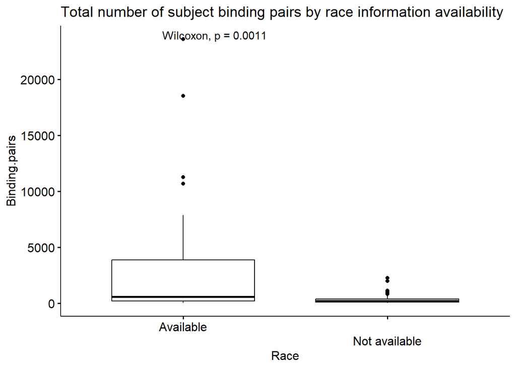

```r
ggboxplot(avail.counts, x = "Race", y = "Binding.pairs") +
  stat_compare_means() +
  ggtitle("Total number of subject binding pairs by race information availability") +
  scale_x_discrete(guide = guide_axis(n.dodge = 2))
```

### Aggregated TCR repertoire data

### Establish counts

Because some ImmuneCODE binding pairs are redundant in other datasets (but have already been filtered out within the ImmuneCODE dataframe), and only ImmuneCODE entries have associated race information, count binding pairs with available race information as:

(number of unique binding pairs with race information) + (number of redundant binding pairs with race information)

```r
# Distribution of samples in each dataset
all.samples.count <- data.frame("Dataset" = c("ImmuneCODE",
                                              #"TCRdb",
                                              "McPAS",
                                              "VDJdb"),
                                "Total.dataset.size" = c(nrow(full[full$Source == "ImmuneCODE", ]),
                                                         nrow(full[full$Source == "McPAS-TCR", ]),
                                                         nrow(full[full$Source == "VDJdb", ])),
                                "Unique.binding.pairs" = c(nrow(full[(full$Source == "ImmuneCODE" & full$Redundant == "Unique"), ]),
                                                           nrow(full[(full$Source == "McPAS-TCR" & full$Redundant == "Unique"), ]),
                                                           nrow(full[(full$Source == "VDJdb" & full$Redundant == "Unique"), ])),
                                "Redundant.binding.pairs" = c(nrow(full[(full$Source == "ImmuneCODE" & full$Redundant == "Redundant"), ]),
                                                              nrow(full[(full$Source == "McPAS-TCR" & full$Redundant == "Redundant"), ]),
                                                              nrow(full[(full$Source == "VDJdb" & full$Redundant == "Redundant"), ])),
                                "Unique.CDR3.sequences" = c(nrow(full[(full$Source == "ImmuneCODE" & full$RedundantTCR == "Unique"), ]),
                                                           nrow(full[(full$Source == "McPAS-TCR" & full$RedundantTCR == "Unique"), ]),
                                                           nrow(full[(full$Source == "VDJdb" & full$RedundantTCR == "Unique"), ])),
                                "Redundant.CDR3.sequences" = c(nrow(full[(full$Source == "ImmuneCODE" & full$RedundantTCR == "Redundant"), ]),
                                                              nrow(full[(full$Source == "McPAS-TCR" & full$RedundantTCR == "Redundant"), ]),
                                                              nrow(full[(full$Source == "VDJdb" & full$RedundantTCR == "Redundant"), ])))

all.samples.count
```

```
##      Dataset Total.dataset.size Unique.binding.pairs Redundant.binding.pairs
## 1 ImmuneCODE             130950               126580                    4370
## 2      McPAS              12256                 7028                    5228
## 3      VDJdb              70489                70442                      47
##   Unique.CDR3.sequences Redundant.CDR3.sequences
## 1                122106                     8844
## 2                  5908                     6348
## 3                 62356                     8133
```

```r
# Get counts
# Unique binding pairs from ImmuneCODE
agg.avail.counts <- data.frame("ImmuneCODE",
                               count(full[(full$Redundant == "Unique" & full$Source == "ImmuneCODE"), ], Availability, name = "Binding.pairs"),
                               count(full[(full$RedundantTCR == "Unique" & full$Source == "ImmuneCODE"), ], Availability, name = "TCR.bioidentities")[2])
colnames(agg.avail.counts)[1] <- "Source"

# Redundant binding pairs
temp <- data.frame("Multiple sources",
                   count(full[full$Redundant == "Redundant", ], Availability, name = "Binding.pairs"),
                   count(full[full$RedundantTCR == "Redundant", ], Availability, name = "TCR.bioidentities")[2])
colnames(temp)[1] <- "Source"
agg.avail.counts <- rbind(agg.avail.counts, temp)

# Unique binding pairs from McPAS-TCR
temp <- data.frame("McPAS-TCR",
                   count(full[(full$Redundant == "Unique" & full$Source == "McPAS-TCR"), ], Availability, name = "Binding.pairs"),
                   count(full[(full$RedundantTCR == "Unique" & full$Source == "McPAS-TCR"), ], Availability, name = "TCR.bioidentities")[2])
colnames(temp)[1] <- "Source"
agg.avail.counts <- rbind(agg.avail.counts, temp)

# Unique binding pairs from VDJdb
temp <- data.frame("VDJdb",
                   count(full[(full$Redundant == "Unique" & full$Source == "VDJdb"), ], Availability, name = "Binding.pairs"),
                   count(full[(full$RedundantTCR == "Unique" & full$Source == "VDJdb"), ], Availability, name = "TCR.bioidentities")[2])
colnames(temp)[1] <- "Source"
agg.avail.counts <- rbind(agg.avail.counts, temp)

agg.avail.counts
```

```
##             Source  Availability Binding.pairs TCR.bioidentities
## 1       ImmuneCODE     Available        109774            105691
## 2       ImmuneCODE Not available         16806             16415
## 3 Multiple sources     Available          3147              7230
## 4 Multiple sources Not available          6498             16095
## 5        McPAS-TCR Not available          7028              5908
## 6            VDJdb Not available         70442             62356
```

#### Dataset contributions and redundancy

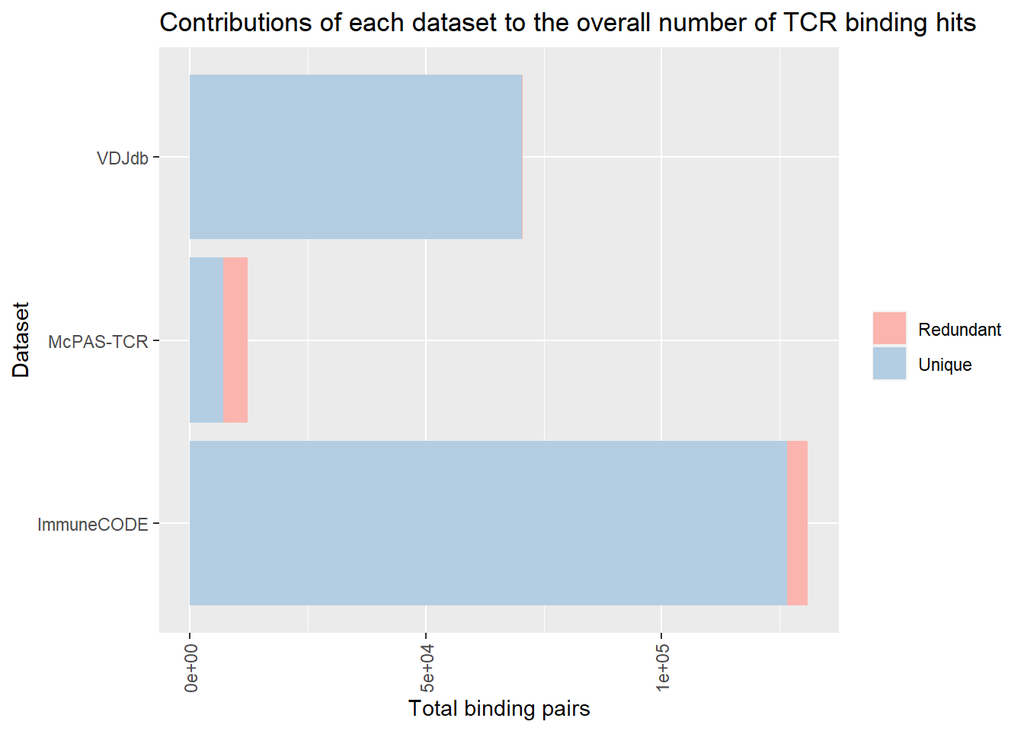

```r
# Aggregated dataset analysis
ggplot(full, aes(x=Source)) +
  coord_flip() +
  geom_bar(stat="count", aes(fill=factor(Redundant))) +
  scale_fill_brewer(palette = "Pastel1") +
  theme(axis.text.x = element_text(angle = 90, vjust = 0.5, hjust=1), legend.title=element_blank()) +
  labs(title="Contributions of each dataset to the overall number of TCR binding hits",
        x ="Dataset", y = "Total binding pairs")
```

#### Overall availability of race information, by binding pairs

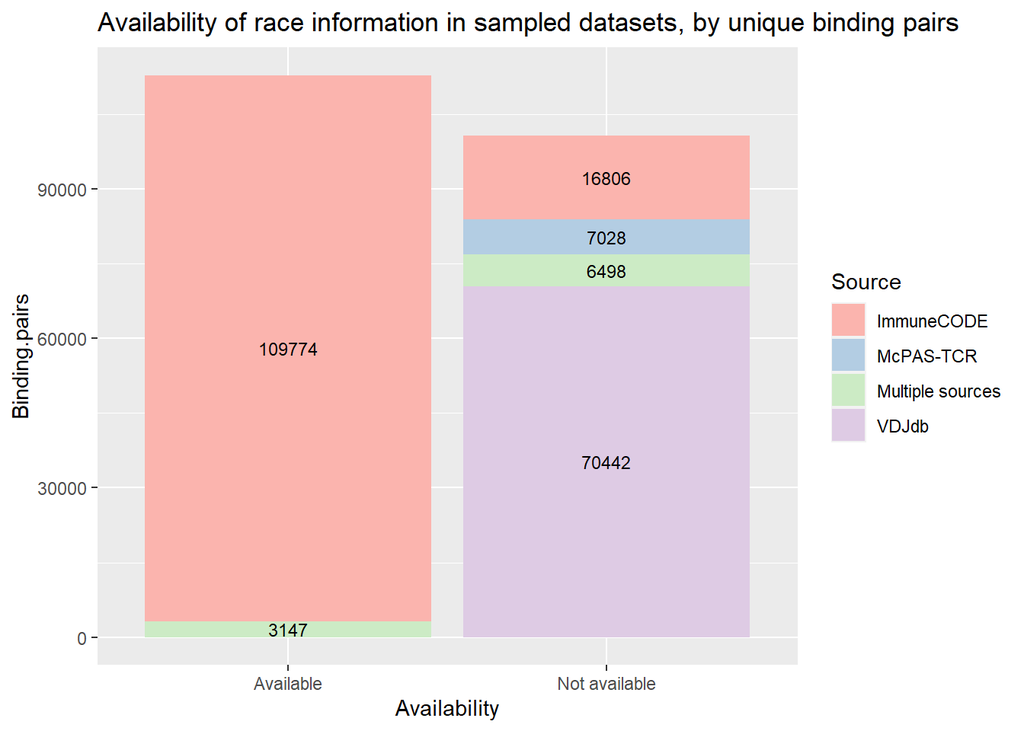

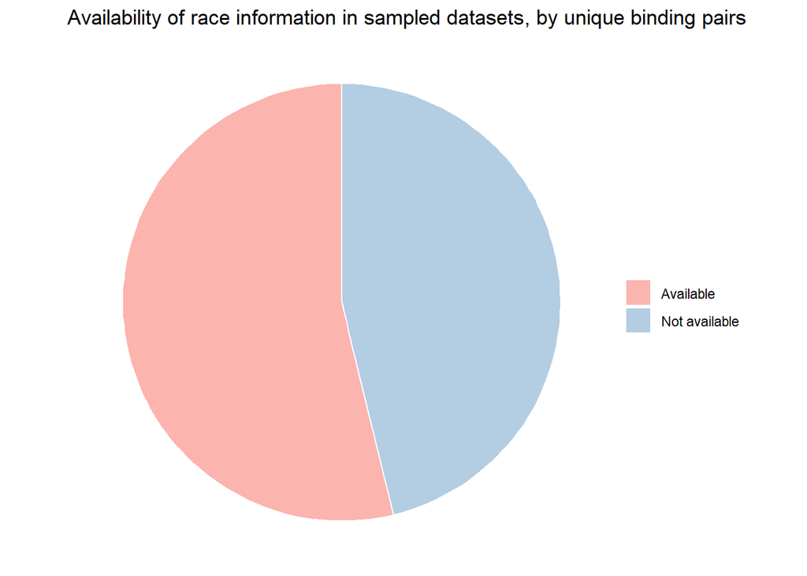

```r
# Distribution of samples with/without ethnicity/race data
ggplot(agg.avail.counts, aes(x= Availability, y= Binding.pairs, fill=Source)) +
  geom_bar(position = "stack", stat = "identity") +
  scale_fill_brewer(palette = "Pastel1") +
  ggtitle("Availability of race information in sampled datasets, by unique binding pairs") +
  geom_text(size = 3, position = position_stack(vjust = 0.5), label=agg.avail.counts$Binding.pairs)

ggplot(full[full$Redundant =="Unique", ], aes(x="", fill=Availability)) +
  geom_bar(stat="count", width=1, color="white") +
  coord_polar("y", start=0) +
  scale_fill_brewer(palette = "Pastel1") +
  theme_void() + ggtitle("Availability of race information in sampled datasets, by unique binding pairs") +
  theme(legend.title=element_blank())
```